# AFDMD-111 - Estadística

Distribuciones muestrales

Cielo Custodio vidal

27/11/2023

# Distribuciones muestrales de la media

En esta práctica abordaremos el tema de la distribución muestral de la media para diversas distribuciones de probabilidad y veremos como éstas se ajustan a una distribución de probabilidad normal o Gaussiana como la que se muestra en la ecuación,

$$f_X(x) = \frac{1}{\sqrt{2\pi \sigma^2}}
\mbox{e}^{-\frac{-(x-\mu)^2}{2\sigma^2}}$$

Antes de iniciar, es necesario que nos familiaricemos con los siguientes comandos:

```r
#hist()
#qqnorm()
#qqline()
```

para ello podemos hacer `help(comando)` y obtener ayuda sobre cada uno de ellos. Ahora responda lo siguiente.

1. ¿Cuál es la función del comando `qqnorm`?.

En R, se utiliza para generar un gráfico de cuantiles normales que facilita la evaluación de la normalidad de un conjunto de datos, permitiendo visualizar si estos siguen una distribución normal.

2. ¿Cuál es la función del comando `qqline`? ¿y de `hist`?.

En R, se usa qqline para agregar una línea de referencia en un gráfico de cuantiles normales, y hist para crear un histograma que representa la distribución de frecuencias de un conjunto de datos.

## Aplicación de `qqnorm` y `qqline`

Veamos ahora la aplicación de `qqnorm` y `qqline` en un ejemplo práctico. Supóngamos que queremos verificar si los datos se ajustan a una distribución normal, entonces para hacerlo, aplicamos,

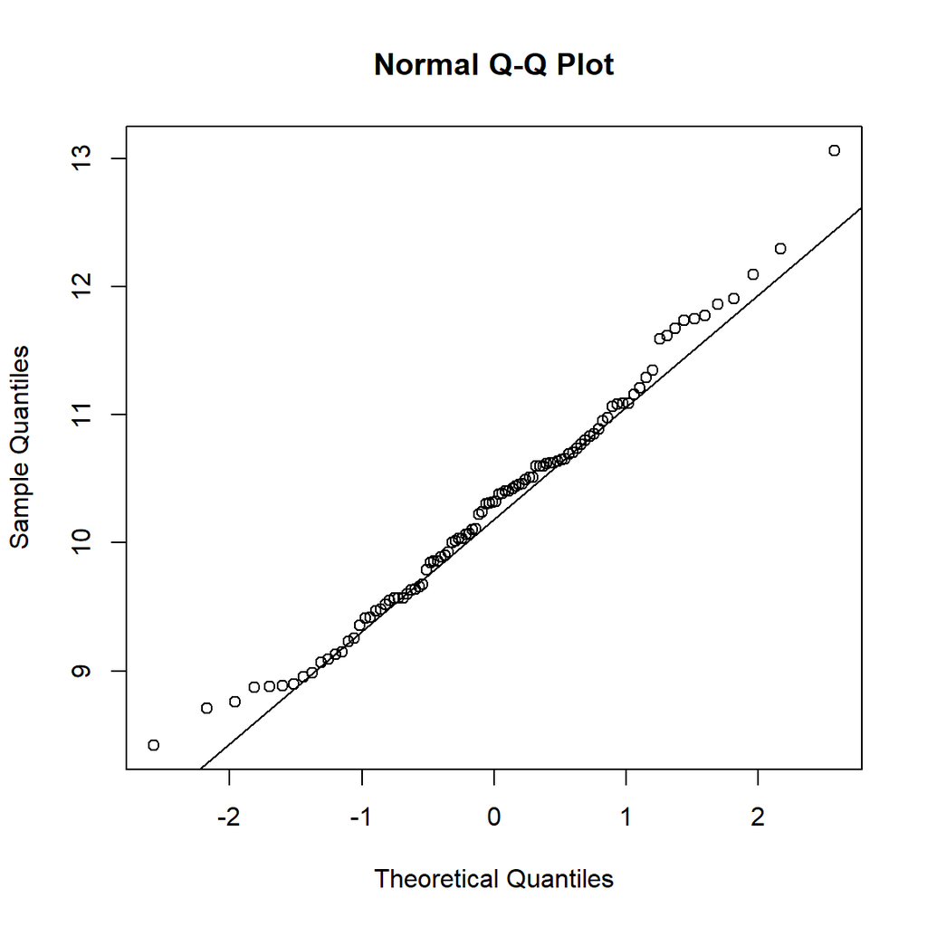

```r
datos <- rnorm(100, mean = 10)
qqnorm(datos)
qqline(datos)
```

Actividad.

1. Ahora cambie los nombres de los ejes $x$, $y$ y del título del gráfico anterior.

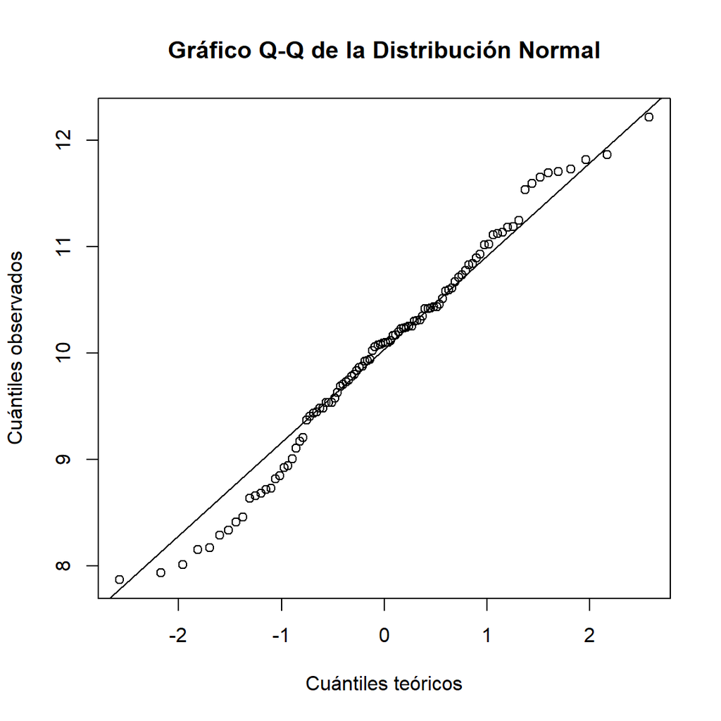

```r
datos <- rnorm(100, mean = 10)
qqnorm(datos,
       xlab = "Cuántiles teóricos",
       ylab = "Cuántiles observados",
       main = "Gráfico Q-Q de la Distribución Normal")
qqline(datos)
```

2. ¿Qué sucede si la longitud de los datos es pequeña, digamos 10, 20 (modifique `rnorm`)?

El gráfico de cuantiles normales puede indicar una distribución no normal.

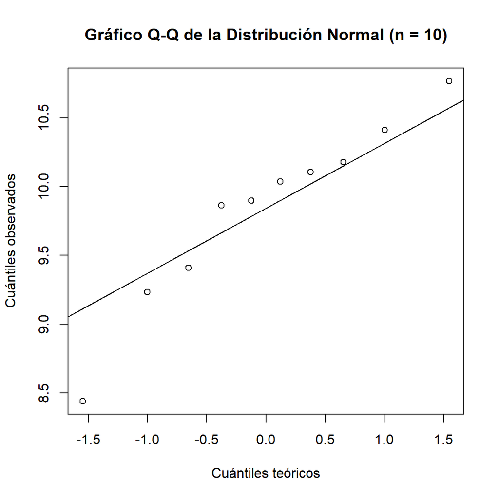

```r
datos_10 <- rnorm(10, mean = 10)
qqnorm(datos_10,
       xlab = "Cuántiles teóricos",
       ylab = "Cuántiles observados",
       main = "Gráfico Q-Q de la Distribución Normal (n = 10)")
qqline(datos_10)
```

3. ¿Qué sucede si los datos tienen varianza grande? ¿En qué parte del gráfico Q-Q se puede ver la varianza grande?

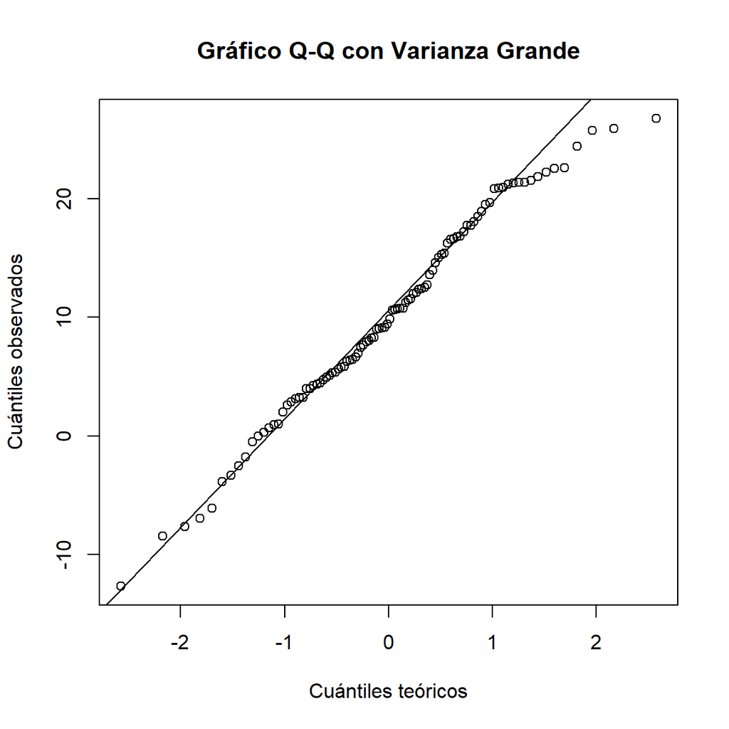

```r
datos_varianza_grande <- rnorm(100, mean = 10, sd = 10)
qqnorm(datos_varianza_grande,
       xlab = "Cuántiles teóricos",
       ylab = "Cuántiles observados",
       main = "Gráfico Q-Q con Varianza Grande")
qqline(datos_varianza_grande)
```

4. ¿Y si cambiamos la media?

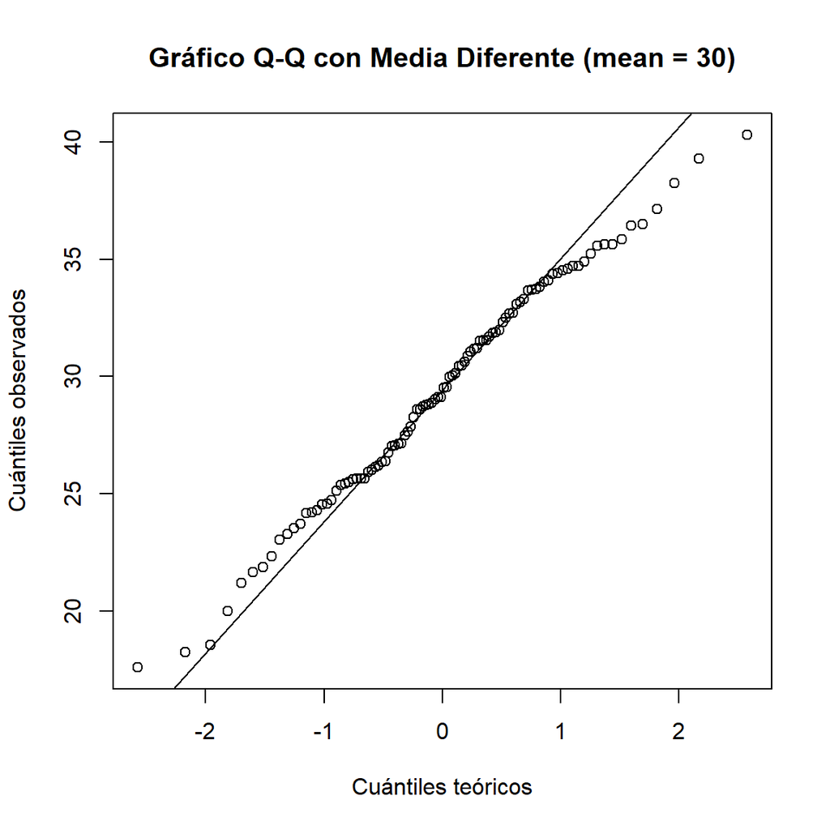

```r
datos_media_diferente <- rnorm(100, mean = 30, sd = 5)
qqnorm(datos_media_diferente,
       xlab = "Cuántiles teóricos",
       ylab = "Cuántiles observados",
       main = "Gráfico Q-Q con Media Diferente (mean = 30)")
qqline(datos_media_diferente)
```

5. ¿Qué sucede si los datos son exponenciales?

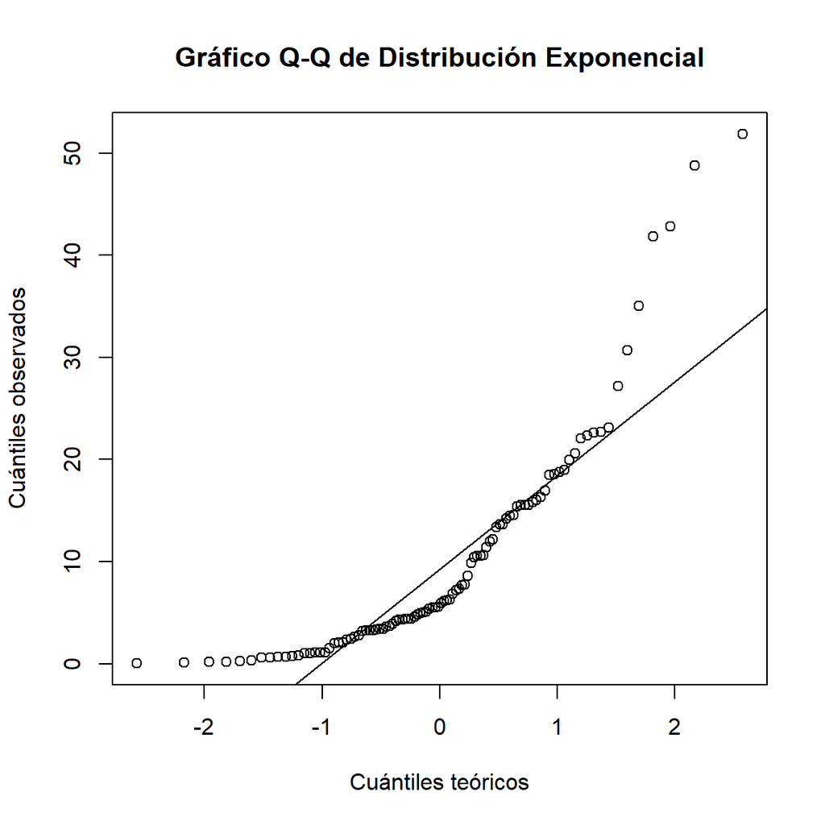

```r
# Datos con distribución exponencial
datos_exponenciales <- rexp(100, rate = 0.1)  # La tasa (rate) es el inverso de la media

qqnorm(datos_exponenciales,
       xlab = "Cuántiles teóricos",
       ylab = "Cuántiles observados",
       main = "Gráfico Q-Q de Distribución Exponencial")
qqline(datos_exponenciales)
```

Desviación de la línea diagonal indica falta de ajuste a distribución normal

## Aplicación de `hist`

El comando `hist` permite obtener el histograma de una serie de datos. El histograma, de igual forma que el gráfico Q-Q permite ajustar una serie de datos a una distribución para saber qué tanto se parece a la densidad teórica. Veamos cómo se aplica.

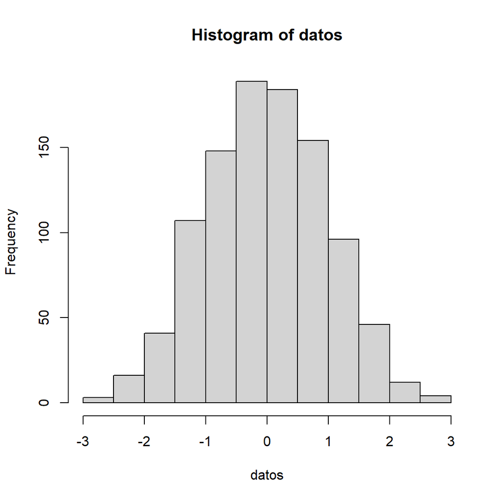

```r
datos <- rnorm(1000) #1000 muestras de una densidad normal
hist(datos)
```

Podemos ver en el gráfico del histograma que éste es similar al gráfico de la densidad. El siguiente código lo muestra:

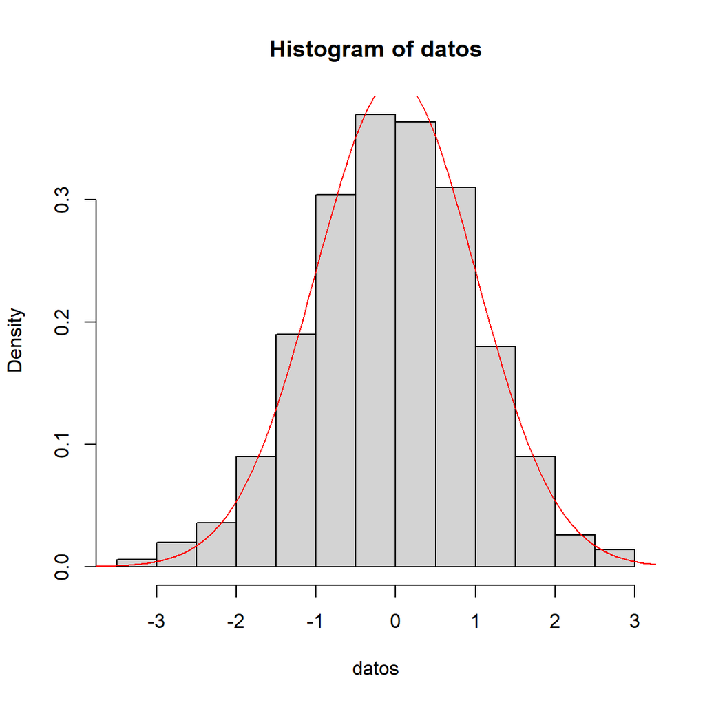

```r
datos <- rnorm(1000) # muestras normales con media 0 y var 1.
teorica <- dnorm(seq(-4,4, length=100),mean = 0, sd = 1)
hist(datos,freq = FALSE)
lines(seq(-4,4, length=100),teorica, col="red")
```

Actividades.

1. ¿Qué sucede si el número de muestras es pequeño (muestrelo mediante código y gráficas)?

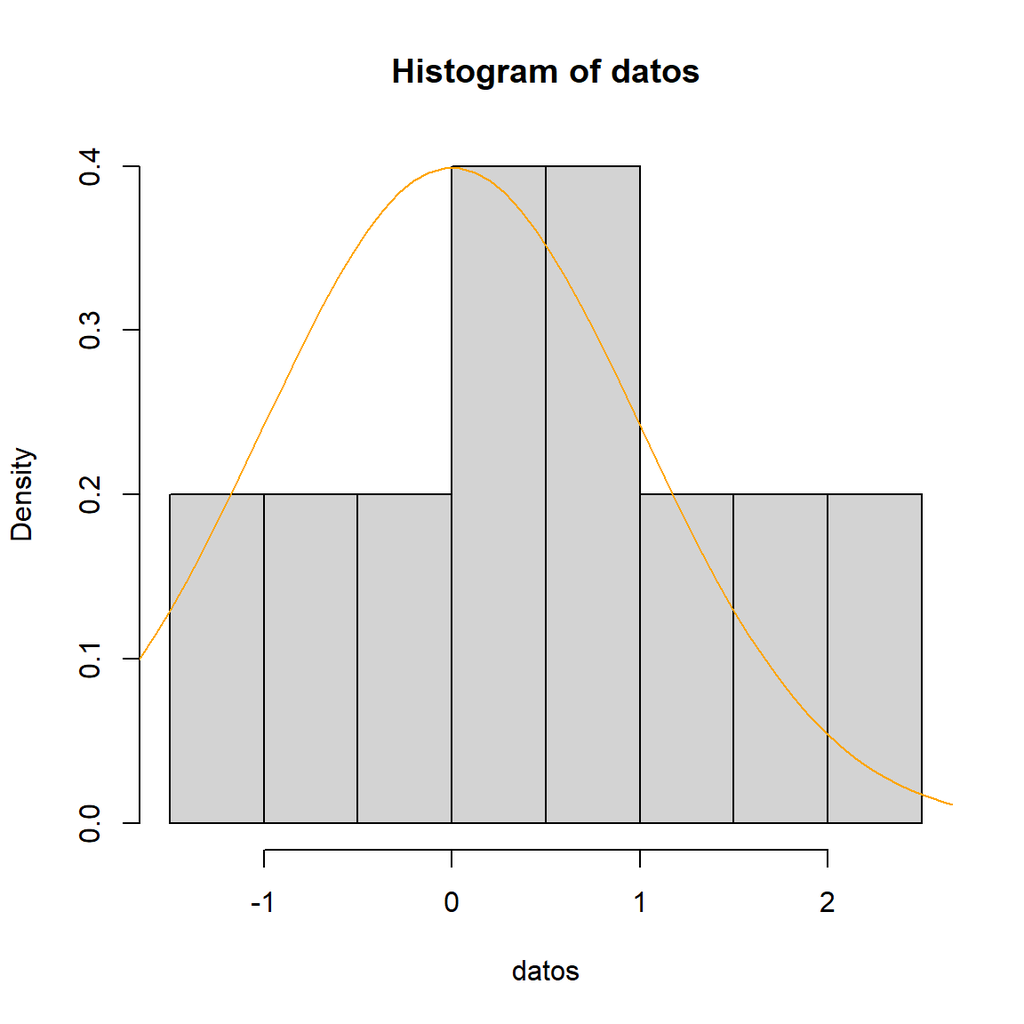

```r
datos <- rnorm(10)
teorica <- dnorm(seq(-4,4, length=100),mean = 0, sd = 1)
hist(datos,freq = FALSE)
lines(seq(-4,4, length=100),teorica, col="orange")
```

Las muestras pueden no reflejar con precisión la forma teórica de distribución

2. ¿Y si cambio la varianza? ¿Tiene algún efecto la varianza grande? Mostrar con código.

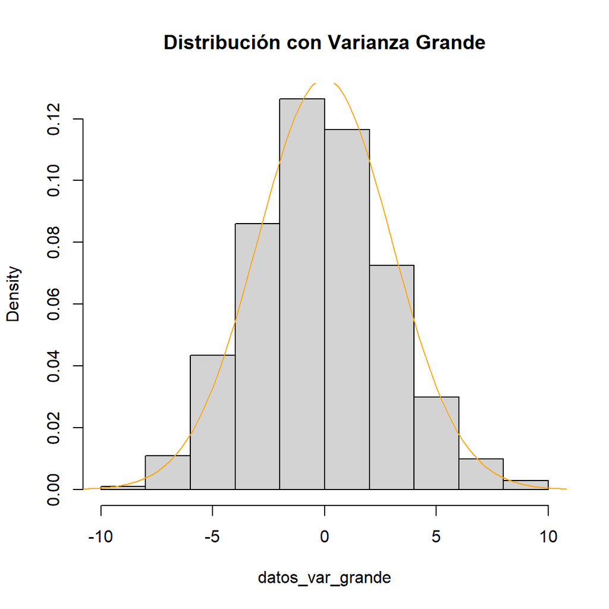

```r
datos_var_grande <- rnorm(1000, mean = 0, sd = 3)
teorica_var_grande <- dnorm(seq(-12, 12, length = 100), mean = 0, sd = 3)
hist(datos_var_grande, freq = FALSE, main = "Distribución con Varianza Grande")
lines(seq(-12, 12, length = 100), teorica_var_grande, col = "orange")
```

Sí, cambiar la varianza afectará la dispersión y la forma de distribución

3. ¿Cuáles crees que son las ventajas y desventajas del histograma y el gráfico Q-Q?

Q-Q son específicos, pero brindan una buena visión general de la distribución

# Aplicación de la distribución muestral de la media.

El término distribución muestral de la media se refiera a la distribución (ajustada mediante el gráfico Q-Q o el histograma) de la media muestral de un conjunto de datos. Por ejemplo,

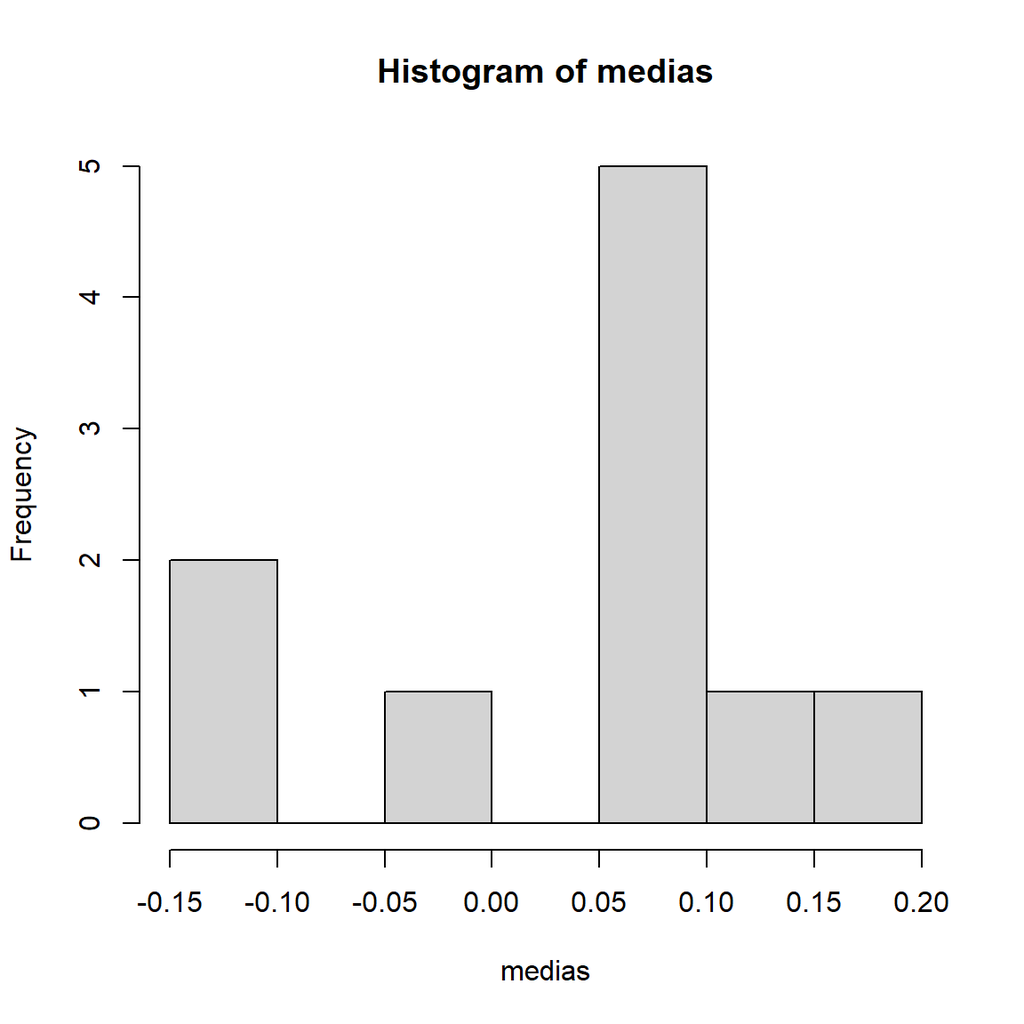

```r
N <- 10 # número de medias (es decir número de muestras)
M <- 100 # número de la longitud de cada serie de datos
medias <- numeric(N) # Vector que guardará las medias

for(i in 1:N)
{
  datos <- rnorm(M)
  medias[i] <- mean(datos)

}
hist(medias)
```

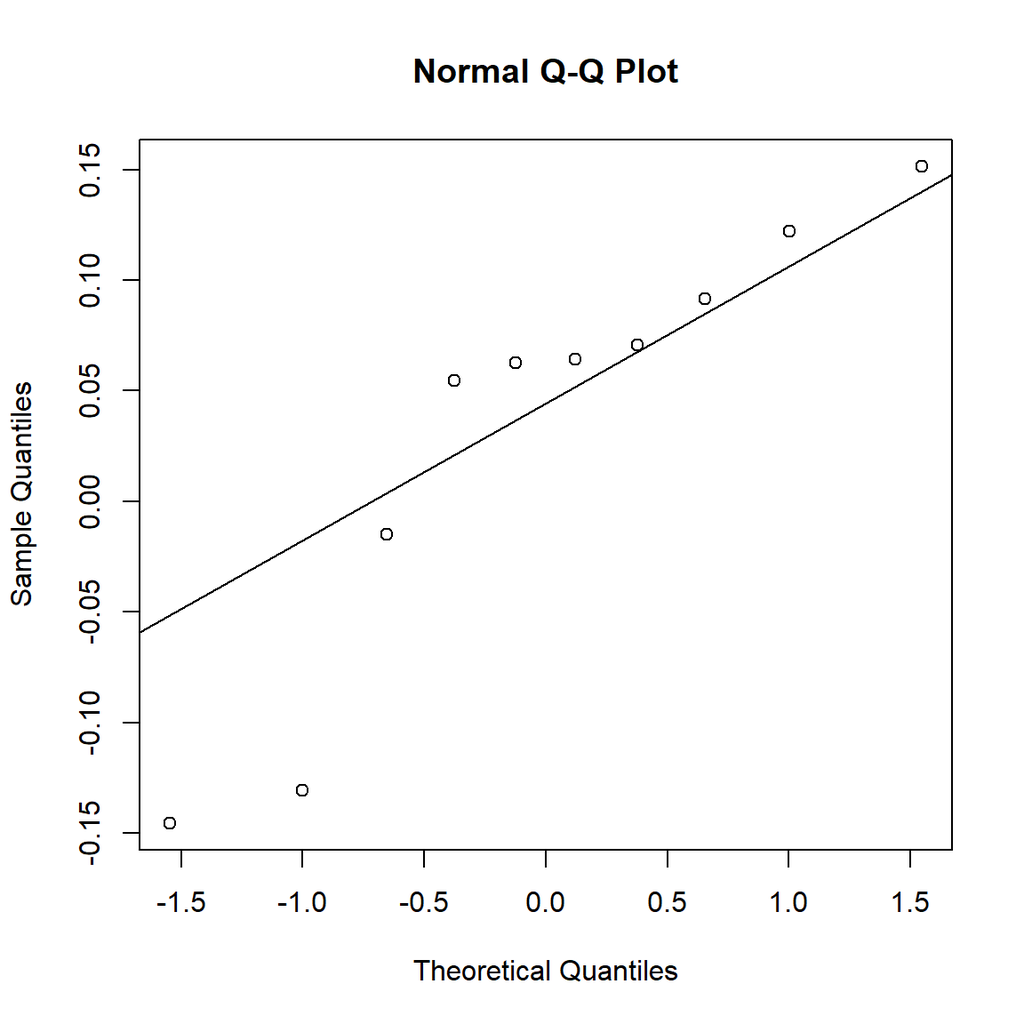

```r
qqnorm(medias)
qqline(medias)
```

Actividad

1. ¿Qué sucede si hago N grande, por ejemplo 100, 1000, 10000?

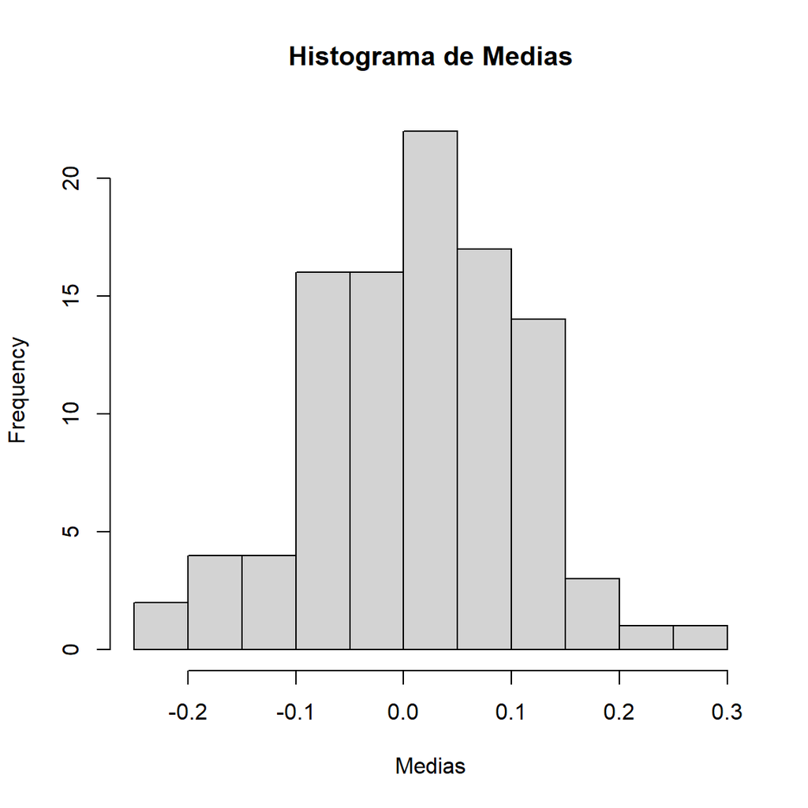

```r
N <- 100
M <- 100
medias <- numeric(N)

for (i in 1:N) {
  datos <- rnorm(M)
  medias[i] <- mean(datos)
}



hist(medias, main = "Histograma de Medias", xlab = "Medias")
```

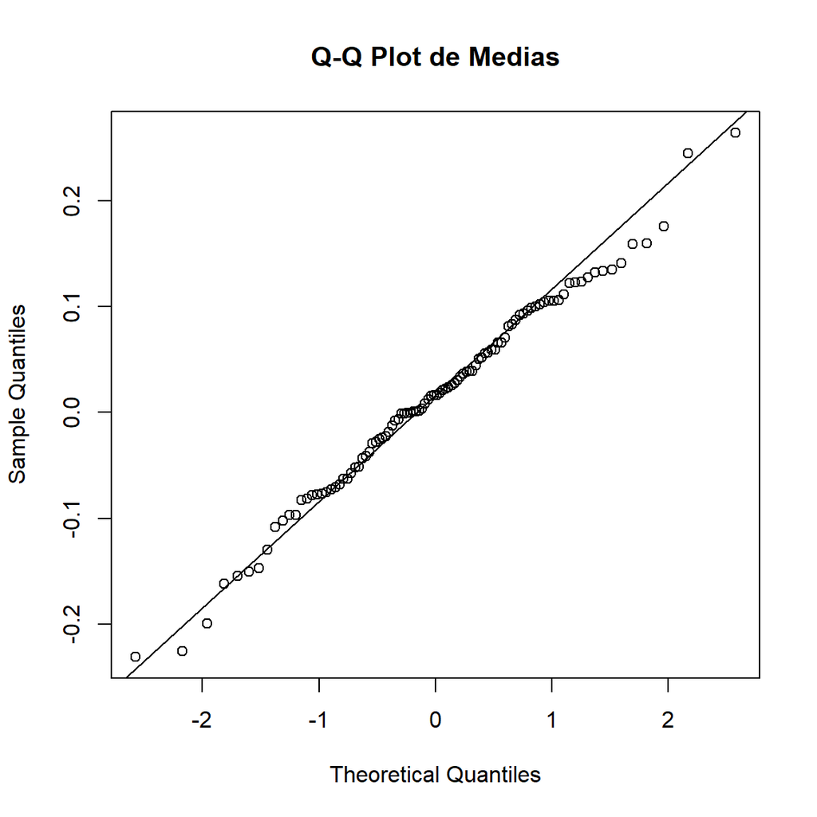

```r
qqnorm(medias, main = "Q-Q Plot de Medias")
qqline(medias)
```

Generar más datos y medias mejora la representación de la distribución al aumentar N.

2. ¿Qué sucede si en lugar de tomar una muestra Gaussiana, tomo una muestra exponencial con N muy grande?

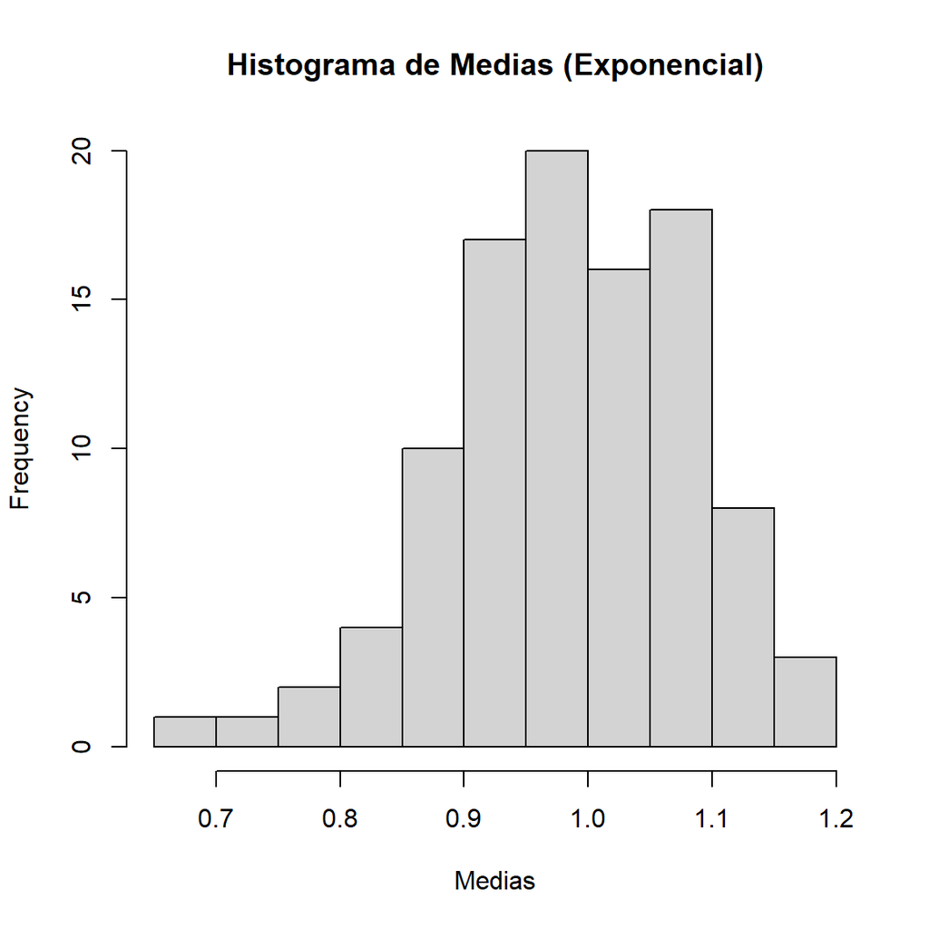

```r
N <- 100
M <- 100
medias <- numeric(N)

for (i in 1:N) {
  datos <- rexp(M)
  medias[i] <- mean(datos)
}


hist(medias, main = "Histograma de Medias (Exponencial)", xlab = "Medias")
```

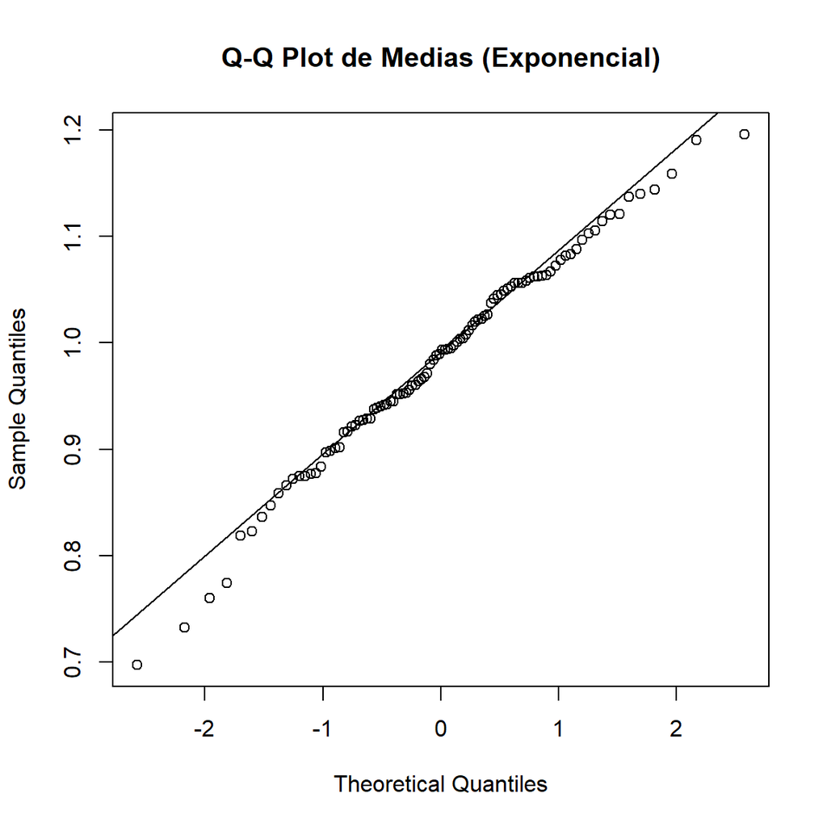

```r
qqnorm(medias, main = "Q-Q Plot de Medias (Exponencial)")
qqline(medias)
```

## Fecha de entrega: Miércoles 29 de Noviembre de 2023 ha las 16:00HRS